# Paso 1

```css
script src = "https://ajax.googleapis.com/ajax/libs/jquery/3.4.1/jquery.min.js"
```

```javascript
 $(document).ready(function() {
    $('body').prepend('<div class=\"zoomDiv\"><img src=\"\" class=\"zoomImg\"></div>');
    // onClick function for all plots (img's)
    $('img:not(.zoomImg)').click(function() {
      $('.zoomImg').attr('src', $(this).attr('src')).css({width: '100%'});
      $('.zoomDiv').css({opacity: '1', width: 'auto', border: '1px solid white', borderRadius: '5px', position: 'fixed', top: '50%', left: '50%', marginRight: '-50%', transform: 'translate(-50%, -50%)', boxShadow: '0px 0px 50px #888888', zIndex: '50', overflow: 'auto', maxHeight: '100%'});
    });
    // onClick function for zoomImg
    $('img.zoomImg').click(function() {
      $('.zoomDiv').css({opacity: '0', width: '0%'});
    });
  });
```

```css
<script src="hideOutput.js"></script>
```

```javascript
$(document).ready(function() {
    $chunks = $('.fold');
    $chunks.each(function () {      // add button to source code chunks
    if ( $(this).hasClass('s') ) {
        $('pre.r', this).prepend("<div class=\"showopt\">Show Source</div><br style=\"line-height:22px;\"/>");
            $('pre.r', this).children('code').attr('class', 'folded');
            }      // add button to output chunks
        if ( $(this).hasClass('o') ) {
            $('pre:not(.r)', this).has('code').prepend("<div class=\"showopt\">Show Output</div><br style=\"line-height:22px;\"/>");
            $('pre:not(.r)', this).children('code:not(r)').addClass('folded');        // add button to plots
            $(this).find('img').wrap('<pre class=\"plot\"></pre>');
            $('pre.plot', this).prepend("<div class=\"showopt\">Show Plot</div><br style=\"line-height:22px;\"/>");
            $('pre.plot', this).children('img').addClass('folded');
            }
});    // hide all chunks when document is loaded
    $('.folded').css('display', 'none')    // function to toggle the visibility
    $('.showopt').click(function() {
            var label = $(this).html();
            if (label.indexOf("Show") >= 0) {
                $(this).html(label.replace("Show", "Hide"));
            } else {
              $(this).html(label.replace("Hide", "Show"));
            }
    $(this).siblings('code, img').slideToggle('fast', 'swing');
    });
});
```

```r
rm(list=ls());gc()
```

```
          used (Mb) gc trigger (Mb) max used (Mb)
Ncells  662026 35.4    1361655 72.8   938723 50.2
Vcells 1180499  9.1    8388608 64.0  2237384 17.1
```

```r
Sys.setlocale("LC_COLLATE", "Spanish_Chile.1252")
```

```
[1] "Spanish_Chile.1252"
```

```r
Sys.setlocale("LC_COLLATE", "Spanish_Chile.1252")
```

```
[1] "Spanish_Chile.1252"
```

```r
Sys.setlocale("LC_CTYPE", "Spanish_Chile.1252")
```

```
[1] "Spanish_Chile.1252"
```

```r
Sys.setlocale("LC_MONETARY", "Spanish_Chile.1252")
```

```
[1] "Spanish_Chile.1252"
```

```r
Sys.setlocale("LC_TIME", "Spanish_Chile.1252")
```

```
[1] "Spanish_Chile.1252"
```

```r
knitr::opts_chunk$set(echo = TRUE)
options(knitr.kable.NA = '')
```

```r
if(!require(pacman)){install.packages("pacman")}
#pacman::p_unlock(lib.loc = pacman::p_path())
pacman::p_load(devtools, car, tidyverse, janitor, imputeTS, sjPlot, zoo, compareGroups, forecast, lubridate, gganimate, data.table, CausalImpact, panelView, ggforce, tsModel, astsa, plm, gsynth, Synth, CausalMBSTS, parallel, doParallel, PanelMatch, kableExtra, Amelia, missRanger, pglm, install=F)
# Calculate the number of cores
no_cores <- detectCores() - 1
cl<-makeCluster(no_cores)
registerDoParallel(cl)
```

# octubre 08, 2022

Cargamos las bases de datos.

```r
REM <- "https://docs.google.com/spreadsheets/u/0/d/1KtdHJ2FLDg4BOUa0KzCw4vawO7lmbZzh/export?format=tsv&id=1KtdHJ2FLDg4BOUa0KzCw4vawO7lmbZzh&gid=1716931764"
destfile <- "_data/brechas_gine_rem.tsv"
curl::curl_download(REM, destfile)
brechas_gine_REM <- readr::read_delim(destfile, delim = "\t",
                      escape_double = FALSE, trim_ws = TRUE)
entradas <- "https://docs.google.com/spreadsheets/u/0/d/1KtdHJ2FLDg4BOUa0KzCw4vawO7lmbZzh/export?format=tsv&id=1KtdHJ2FLDg4BOUa0KzCw4vawO7lmbZzh&gid=1847489841"
destfile <- "_data/brechas_gine_entradas.tsv"
curl::curl_download(entradas, destfile)
brechas_gine_entradas <- readr::read_delim(destfile, delim = "\t",
                      escape_double = FALSE, trim_ws = TRUE)
le <- "https://docs.google.com/spreadsheets/u/0/d/1KtdHJ2FLDg4BOUa0KzCw4vawO7lmbZzh/export?format=tsv&id=1KtdHJ2FLDg4BOUa0KzCw4vawO7lmbZzh&gid=1987038231"
destfile <- "_data/brechas_gine_le.tsv"
curl::curl_download(le, destfile)
brechas_gine_le <- readr::read_delim(destfile, delim = "\t",
                      escape_double = FALSE, trim_ws = TRUE)
```

# Consolidación de base de datos

Considerando el diseño ecológico de este estudio, que utiliza y analiza información de bases de datos secundarias, no fue necesario obtener aprobación de comité de ética acreditado y por lo tanto, tampoco un proceso de consentimiento informado

## Paso 1. Limpiar las variables

Primero normalizamos y restringimos los nombres de cada base de datos, luego restringimos el resto de las bases de datos de acuerdo a los años y meses disponibles en la base de datos `REM` (Enero 2018 a Junio 2022), agrupando la suma de prestaciones de origen en la institución de destino por tipo de prestación, año y mes. Finalmente, combinamos las bases de datos.

```r
#https://cran.r-project.org/web/packages/PanelMatch/vignettes/using_panelmatch.pdf
#https://cran.r-project.org/web/packages/PanelMatch/vignettes/matched_set_objects.html
#https://cran.r-project.org/web/packages/pampe/pampe.pdf}

#table(brechas_gine_entradas $ESTAB_DEST, brechas_gine_entradas $ESTAB_DEST_NOMBRE)
#07-058     GINECOLOGIA
#114101     HOSPITAL DR. SÓTERO DEL RÍO
#114103     HOSPITAL PADRE HURTADO
#200282     CRS PUENTE ALTO HOSPITAL PROVINCIA CORDILLERA
#114105     HOSPITAL ELOISA DIAZ

#seleccionamos los años y meses disponibles de la base original
vector_ano_mes<-
janitor::clean_names(brechas_gine_REM) %>% dplyr::mutate(ano_mes=paste0(ano,"_",sprintf("%.2d", mes))) %>% distinct(ano_mes)

#_#_#_#_#_#_#_#_
#_#_#_#_#_#_#_#_ENTRADAS
#_#_#_#_#_#_#_#_
brechas_gine_entradas_mod<-
janitor::clean_names(brechas_gine_entradas)[,c("estab_dest", "presta_min", "ano", "mes", "n_entradas")] %>%
  dplyr::arrange(estab_dest, presta_min, ano, mes) %>%
  #para cada establecimiento, prestación y año, genero valores con los distintos meses del año si no están
  dplyr::group_by(estab_dest, presta_min, ano) %>%
  tidyr::complete(mes = seq(1, 12)) %>%
  dplyr::ungroup() %>%
  #generamos una variable llamada ano-mes, para homologar nuestros datos a la base original
  dplyr::mutate(ano_mes=paste0(ano,"_",sprintf("%.2d", mes))) %>%
  dplyr::group_by(estab_dest, presta_min, ano_mes, ano, mes) %>%
  dplyr::summarise(n_entradas_tot=sum(n_entradas, na.rm=T)) %>%
  #dplyr::filter(ano_mes=="2020_05")

#_#_#_#_#_#_#_#_
  dplyr::ungroup() %>%
  #filtro para que coincida con la base de datos de REM
  dplyr::filter(ano_mes %in% unlist(vector_ano_mes))#%>%
#_#_#_#_#_#_#_#_LE
#_#_#_#_#_#_#_#_
brechas_gine_le_mod<-
janitor::clean_names(brechas_gine_le)[,c("estab_dest", "presta_min", "ano_13", "mes_14", "n_registros")] %>%
  dplyr::arrange(estab_dest, presta_min, ano_13, mes_14) %>%
  #seleccionamos la primera fila para cada uno
  dplyr::group_by(estab_dest, presta_min, ano_13, mes_14) %>%
  dplyr::summarise(sum_le=sum(n_registros, na.rm=T)) %>%
  dplyr::ungroup() %>%
  #para cada establecimiento, prestación y año, genero valores con los distintos meses del año si no están
  #dplyr::group_by(estab_dest, presta_min, ano_13) %>%
  tidyr::complete(mes_14 = seq(1, 12)) %>%
  #generamos una variable llamada ano-mes, para homologar nuestros datos a la base original
  dplyr::mutate(ano_mes=paste0(ano_13,"_",sprintf("%.2d", mes_14))) %>%
  dplyr::ungroup() %>%
  #filtro para que coincida con la base de datos de REM
  dplyr::filter(ano_mes %in% unlist(vector_ano_mes))

#LEM= lista espera mensual
#LET = lista espera trimestral
#Hacer lo mismo con la LElas entradas por mes

#_#_#_#_#_#_#_#_#_#_#_#_#_#_#_#_#_#_#_#_#_#_#_#_#_#_#_#_#_#_#_#_#_#_#_#_#_#_#_#_
#_#_#_#_#_#_#_#_#_#_#_#_#_#_#_#_#_#_#_#_#_#_#_#_#_#_#_#_#_#_#_#_#_#_#_#_#_#_#_#_
# COMBINACION DE BASES
#_#_#_#_#_#_#_#_#_#_#_#_#_#_#_#_#_#_#_#_#_#_#_#_#_#_#_#_#_#_#_#_#_#_#_#_#_#_#_#_

cons_brechas_gine<-
brechas_gine_REM %>%
  janitor::clean_names() %>%
  dplyr::select(cod_deis, ano, mes, trimestre, cod_sigte, rem_consulta, rem_consulta_nueva, rem_consulta_control, rem_pertinentes, rem_nsp, rem_altas) %>%
    dplyr::arrange(cod_deis, ano, mes, cod_sigte) %>%
  dplyr::left_join(brechas_gine_entradas_mod[,setdiff(names(brechas_gine_entradas_mod),"ano_mes")], by=c("cod_deis"="estab_dest", "cod_sigte"="presta_min", "ano"="ano", "mes"="mes"))%>%
  dplyr::left_join(brechas_gine_le_mod[,setdiff(names(brechas_gine_le_mod),"ano_mes")], by=c("cod_deis"="estab_dest", "cod_sigte"="presta_min", "ano"="ano_13", "mes"="mes_14")) %>%
  dplyr::mutate(across(c("rem_consulta_nueva", "rem_pertinentes", "rem_nsp", "rem_altas", "n_entradas_tot"),~ifelse(.==0, NA,.))) %>%
  dplyr::rename("entradas"="n_entradas_tot")%>%
  dplyr::mutate(razon_do=rem_consulta_nueva/entradas) %>%
  #
  dplyr::mutate(fecha=as.Date(paste0(ano,"_",mes,"_01"),"%Y_%m_%d")) %>%
  dplyr::mutate(trat=dplyr::case_when(ano==2020 & mes>= 4~1,T~ 0))
cons_brechas_gine<-
dplyr::mutate(cons_brechas_gine,lev_ano_mes= as.numeric(factor(paste0(ano,"_",sprintf("%.2d", mes)),levels=vector_ano_mes$ano_mes))) %>%
  dplyr::mutate(id=paste0(cod_deis,"_",cod_sigte))
```

A `200282 CRS PUENTE ALTO HOSPITAL PROVINCIA CORDILLERA` no tenía ninguna información para mayo del 2020. La base de LE’s está bastante más incompleta en ese sentido. Además tiene meses 0 (ej., 2020- 0). Todavía no sé que es LEM. Aquellas columnas `rem_` en algunos casos tienen valores 0, pero posiblemente son datos perdidos. Con todo, se consolidó una base de datos llamada `cons_brechas_gine`.

```r
pv_data<-
panelView::panelview(entradas ~trat, data=cons_brechas_gine, index = c("cod_deis","fecha"))
```

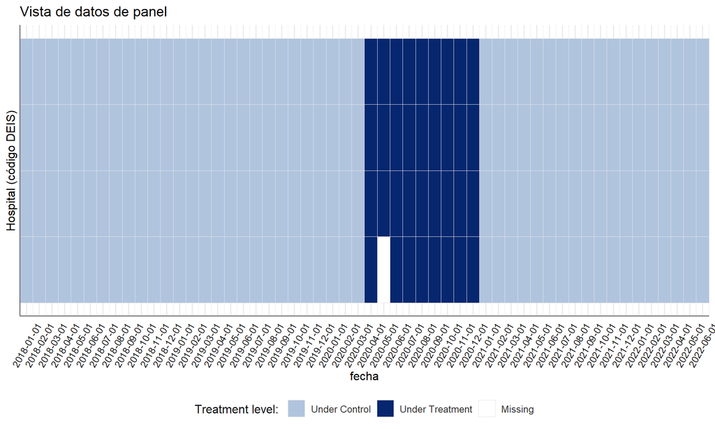

```r
pv_data+
  sjPlot::theme_sjplot2()+
    theme(axis.text.x = element_text(vjust = 0.5,hjust = 0.5,angle = 60),
          legend.position="bottom",
          plot.caption=element_text(hjust=0))+
    scale_y_continuous(breaks=seq(0,1000,50))+
  ggtitle("Vista de datos de panel")+
  ylab("Hospital (código DEIS)")
```

Posteriormente, para reemplazar datos perdidos, se utilizó un modelo de imputación de series de tiempo por cada institución y código de prestación basado en suavizamiento (*smoothing*) Kalman correspondiente a modelos de series de tiempo estructurales. Se consolidaron los datos en una base de datos con nombre `cons_brechas_gine_imp`.

```r
bd_forloop<- expand.grid(cod_deis=unique(cons_brechas_gine$cod_deis), cod_sigte=unique(cons_brechas_gine$cod_sigte))

vec_columnas<-
c("rem_consulta", "rem_consulta_nueva", "rem_consulta_control", "rem_pertinentes", "rem_nsp", "rem_altas", "entradas", "sum_le")

df<-data.frame()
for (x in 1:length(vec_columnas)){
  i<-vec_columnas[x]
  for (val in 1:nrow(bd_forloop)){
    j1<- bd_forloop[val,"cod_deis"]
    j2<- bd_forloop[val,"cod_sigte"]
    paste0("Casos de cod= ",j1," cod_sigte= ",j2," para columna ",i)
    set.seed(2125)
    imp<-imputeTS::na_kalman(subset(cons_brechas_gine, cod_deis==j1 & cod_sigte==j2, i))[[1]]
    ano_mes<-subset(cons_brechas_gine, cod_deis==j1 & cod_sigte==j2, c("ano","mes"))
    df<-
    bind_rows(df,cbind.data.frame(
                     cod_deis= rep(j1,length(imp)), cod_sigte= rep(j2,length(imp)), value=rep(i,length(imp)),
                     ano=ano_mes[,1],
                     mes=ano_mes[,2],
                     imp=as.numeric(imp)))
  }
}
invisible("Opción A, imputación con KALMAN para cada serie")
cons_brechas_gine_a_imp<-
tidyr::pivot_wider(df,names_from ="value", values_from=imp)%>%
  dplyr::mutate(fecha=as.Date(paste0(ano,"_",mes,"_01"),"%Y_%m_%d")) %>%
  dplyr::mutate(trat=dplyr::case_when(ano==2020 & mes>= 4~1,T~ 0))%>%
  dplyr::mutate(razon_do=rem_consulta_nueva/entradas) %>%
  dplyr::mutate(lev_ano_mes= as.numeric(factor(paste0(ano,"_",sprintf("%.2d", mes)),levels=vector_ano_mes$ano_mes)))%>%
  dplyr::mutate(id=paste0(cod_deis,"_",cod_sigte))

cons_brechas_gine_imp_a_wide<-
  cons_brechas_gine_a_imp %>%
  dplyr::mutate(trat=dplyr::case_when(mes>= 4~1,T~ 0))%>%
  data.frame() %>%
tidyr::pivot_wider(id_cols=c(cod_deis, cod_sigte, trat, mes),names_from ="ano", values_from=c(vec_columnas, "razon_do"))
```

```r
invisible("Opción B, imputación con forest trees: missranger")

set.seed(2125)
cons_brechas_gine_b_imp <- missRanger::missRanger(dplyr::mutate(dplyr::select(cons_brechas_gine,id,lev_ano_mes,rem_consulta, rem_consulta_nueva, rem_consulta_control, rem_pertinentes, rem_nsp, rem_altas, entradas, sum_le),rn=row_number()), . ~ . - id -rn, pmm.k = 6, num.trees = 500)
```

```
Missing value imputation by random forests

  Variables to impute:      rem_consulta_nueva, rem_pertinentes, rem_nsp, rem_altas, entradas, sum_le
  Variables used to impute: lev_ano_mes, rem_consulta, rem_consulta_nueva, rem_consulta_control, rem_pertinentes, rem_nsp, rem_altas, entradas, sum_le
iter 1: ......
iter 2: ......
iter 3: ......
iter 4: ......
```

```r
cons_brechas_gine_b_imp <-
  cons_brechas_gine_b_imp %>%
    tidyr::separate(id,c("cod_deis", "cod_sigte"),sep="_") %>%
    dplyr::mutate(razon_do=rem_consulta_nueva/entradas) %>%
    dplyr::left_join(cbind(rn=1:length(vector_ano_mes$ano_mes),vector_ano_mes), by=c("lev_ano_mes"="rn")) %>%
  dplyr::mutate(id=paste0(cod_deis,"_",cod_sigte))%>%
  data.frame() %>%
  tidyr::separate(ano_mes, c("ano","mes"),sep="_") %>%
  dplyr::mutate(mes=as.numeric(mes))  %>%
  dplyr::mutate(trat=dplyr::case_when(ano==2020 & mes>= 4~1,T~ 0))%>%
  dplyr::mutate(fecha=as.Date(paste0(ano,"_",mes,"_01"),"%Y_%m_%d")) %>%
  dplyr::mutate(lev_ano_mes= as.numeric(factor(paste0(ano,"_",sprintf("%.2d", mes)),levels=vector_ano_mes$ano_mes)))

cons_brechas_gine_imp_b_wide<-
  cons_brechas_gine_b_imp %>%
  dplyr::mutate(trat=dplyr::case_when(mes>= 4~1,T~ 0))%>%
tidyr::pivot_wider(id_cols=c(cod_deis, cod_sigte, trat, mes),names_from ="ano", values_from=c(vec_columnas, "razon_do"))
```

```r
#_#_#_#_#_#_#_#_#_#_#_#_#_#_#_#_#_#_#_#_#_#_#_#_
#_#_#_#_#_#_#_#_#_#_#_#_#_#_#_#_#_#_#_#_#_#_#_#_
#https://fondecytacc.github.io/SUD_health_Chile.github.io/Matching_Process1_APR_22#Imputation
set.seed(2125)
amelia_fit <- amelia(dplyr::mutate(dplyr::select(cons_brechas_gine,id,lev_ano_mes,rem_consulta, rem_consulta_nueva, rem_pertinentes, rem_nsp, rem_altas, entradas, sum_le),rn=row_number()) %>% data.frame(),
                      m=50,
                      parallel = "multicore", #noms = "row",
                      idvars="rn",#"hash_key","rn"
                      #noms= c("cod_deis"),
                      #ords= c("trimestre"),
                      cs = "id",
                      ts = "lev_ano_mes",
                      incheck = TRUE)
#no es muy bueno
compare.density(amelia_fit,var="sum_le")
```

Se añaden 0’s y 1’s para indicar cuando son tratamientos de cuando no.

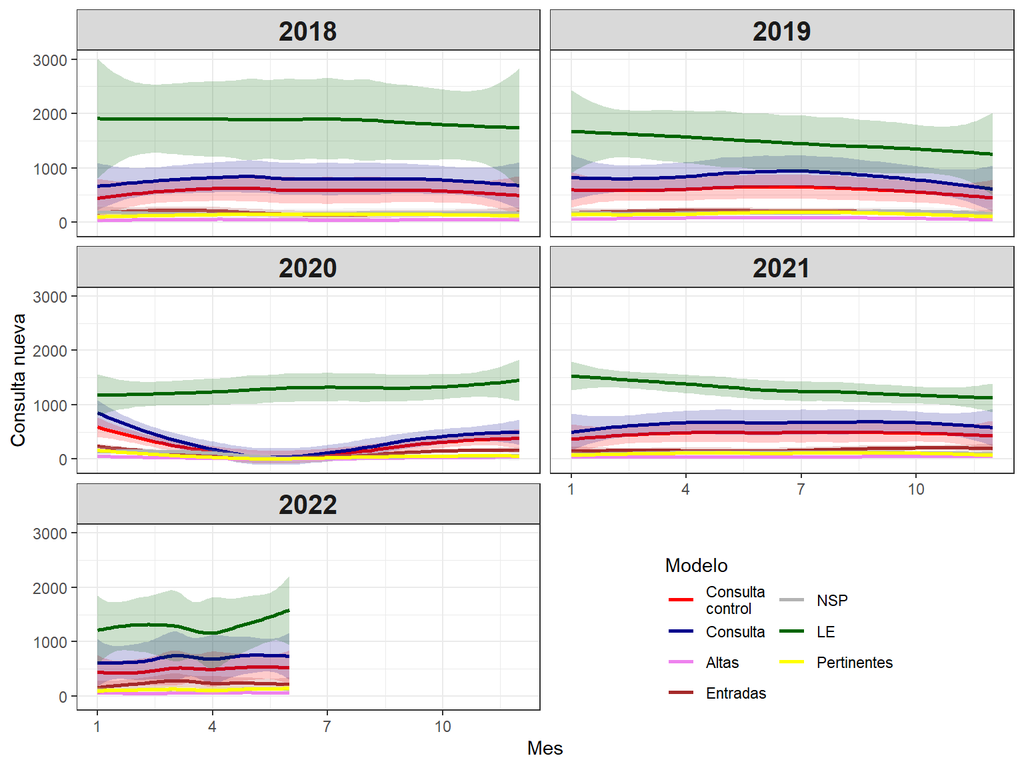

```r
#https://choonghyunryu.github.io/dlookr/reference/get_transform.html
#vec_columnas
cons_brechas_gine_a_imp%>%
ggplot() + #median
  facet_wrap(~ano, ncol = 2) +
  theme_bw() +
  ylab("Consulta nueva") +
  xlab("Mes") +
  theme(strip.text.x = element_text(size = 15, face = "bold"),
        legend.position = c(.75,0.12),
        plot.caption=element_text(hjust = 0),
        legend.key = element_rect(fill = NA))+
  stat_smooth(aes(y = rem_consulta_control, x = mes, color = 'red'), fill = 'red', alpha = 0.2,fun.data = median_hilow, fun.args = list(conf.int = 0.5))+
  stat_smooth(aes(y = rem_consulta, x = mes, color = 'darkblue'), fill = 'darkblue', alpha = 0.2,fun.data = median_hilow, fun.args = list(conf.int = 0.5))+
  stat_smooth(aes(y = rem_altas, x = mes, color = 'violet'), fill = 'violet', alpha = 0.2,fun.data = median_hilow, fun.args = list(conf.int = 0.5))+
  stat_smooth(aes(y = entradas, x = mes, color = 'brown'), fill = 'brown', alpha = 0.2,fun.data = median_hilow, fun.args = list(conf.int = 0.5))+
  stat_smooth(aes(y = rem_nsp, x = mes, color = 'gray70'), fill = 'gray80', alpha = 0.2,fun.data = median_hilow, fun.args = list(conf.int = 0.5))+
  stat_smooth(aes(y = sum_le, x = mes, color = 'darkgreen'), fill = 'darkgreen', alpha = 0.2, fun.data = median_hilow, fun.args = list(conf.int = 0.5))+
  stat_smooth(aes(y = rem_pertinentes, x = mes, color = 'yellow'), fill = 'yellow', alpha = 0.2, fun.data = median_hilow, fun.args = list(conf.int = 0.5))+
  scale_color_identity(name = "Modelo",
                          breaks = c("red", "darkblue", "violet","brown","gray70","darkgreen","yellow"),
                          labels = c("Consulta\ncontrol", "Consulta", "Altas","Entradas", "NSP","LE", "Pertinentes"),
                          guide = "legend")+
    scale_x_continuous(
  breaks = seq(from = 1, to = 12, by =3))+
  guides(color=guide_legend(ncol=2,
  override.aes=list(fill=NA)))
```

## Paso 2. Explorar trayectorias

Para hacer efectos mixtos, debería ver la cantidad de casos acumulados y el log de eso, asumiendo exponencialidad por recuento de casos. También explorar si hay algún efecto de autocorrelación.

```r
cons_brechas_gine_a_imp%>%
  #dplyr::filter(lev_ano_mes %in% 6:26) %>%
  knitr::kable("markdown", caption="Muestra de los datos (imp A)")
```

Table 1: Muestra de los datos (imp A)

| cod_deis | cod_sigte | ano | mes | rem_consulta | rem_consulta_nueva | rem_consulta_control | rem_pertinentes | rem_nsp | rem_altas | entradas | sum_le | fecha | trat | razon_do | lev_ano_mes | id |
| --- | --- | --- | --- | --- | --- | --- | --- | --- | --- | --- | --- | --- | --- | --- | --- | --- |
| 114101 | 07-058 | 2018 | 1 | 1086 | 209.00000 | 877 | 82.00000 | 182.000000 | 106.000000 | 226.00000 | 1646.84456 | 2018-01-01 | 0 | 0.9247788 | 1 | 114101_07-058 |
| 114101 | 07-058 | 2018 | 2 | 708 | 148.00000 | 560 | 64.00000 | 166.000000 | 84.000000 | 404.00000 | 1643.89544 | 2018-02-01 | 0 | 0.3663366 | 2 | 114101_07-058 |
| 114101 | 07-058 | 2018 | 3 | 1239 | 333.00000 | 906 | 146.00000 | 147.000000 | 121.000000 | 477.00000 | 1640.15249 | 2018-03-01 | 0 | 0.6981132 | 3 | 114101_07-058 |
| 114101 | 07-058 | 2018 | 4 | 1289 | 298.00000 | 991 | 138.00000 | 192.000000 | 173.000000 | 418.00000 | 1635.43777 | 2018-04-01 | 0 | 0.7129187 | 4 | 114101_07-058 |
| 114101 | 07-058 | 2018 | 5 | 1212 | 285.00000 | 927 | 99.00000 | 224.000000 | 129.000000 | 9.00000 | 1629.57332 | 2018-05-01 | 0 | 31.6666667 | 5 | 114101_07-058 |
| 114101 | 07-058 | 2018 | 6 | 1197 | 304.00000 | 893 | 148.00000 | 163.000000 | 133.000000 | 12.00000 | 1622.38119 | 2018-06-01 | 0 | 25.3333333 | 6 | 114101_07-058 |
| 114101 | 07-058 | 2018 | 7 | 999 | 263.00000 | 736 | 97.00000 | 146.000000 | 86.000000 | 12.00000 | 1613.68343 | 2018-07-01 | 0 | 21.9166667 | 7 | 114101_07-058 |
| 114101 | 07-058 | 2018 | 8 | 1407 | 341.00000 | 1066 | 143.00000 | 248.000000 | 107.000000 | 16.00000 | 1657.00000 | 2018-08-01 | 0 | 21.3125000 | 8 | 114101_07-058 |
| 114101 | 07-058 | 2018 | 9 | 939 | 222.00000 | 717 | 113.00000 | 154.000000 | 85.000000 | 18.00000 | 1563.00000 | 2018-09-01 | 0 | 12.3333333 | 9 | 114101_07-058 |
| 114101 | 07-058 | 2018 | 10 | 1373 | 400.00000 | 973 | 228.00000 | 208.000000 | 129.000000 | 324.00000 | 1275.00000 | 2018-10-01 | 0 | 1.2345679 | 10 | 114101_07-058 |
| 114101 | 07-058 | 2018 | 11 | 1188 | 357.00000 | 831 | 208.00000 | 165.000000 | 114.000000 | 202.00000 | 1324.00000 | 2018-11-01 | 0 | 1.7673267 | 11 | 114101_07-058 |
| 114101 | 07-058 | 2018 | 12 | 1058 | 339.00000 | 719 | 196.00000 | 149.000000 | 99.000000 | 240.00000 | 1198.00000 | 2018-12-01 | 0 | 1.4125000 | 12 | 114101_07-058 |
| 114101 | 07-058 | 2019 | 1 | 1452 | 386.00000 | 1066 | 180.00000 | 283.000000 | 119.000000 | 71.00000 | 931.00000 | 2019-01-01 | 0 | 5.4366197 | 13 | 114101_07-058 |
| 114101 | 07-058 | 2019 | 2 | 892 | 245.00000 | 647 | 114.00000 | 174.000000 | 88.000000 | 178.00000 | 891.00000 | 2019-02-01 | 0 | 1.3764045 | 14 | 114101_07-058 |
| 114101 | 07-058 | 2019 | 3 | 1331 | 300.00000 | 1031 | 120.00000 | 219.000000 | 163.000000 | 268.00000 | 809.00000 | 2019-03-01 | 0 | 1.1194030 | 15 | 114101_07-058 |
| 114101 | 07-058 | 2019 | 4 | 1341 | 336.00000 | 1005 | 162.00000 | 205.000000 | 142.000000 | 282.00000 | 636.00000 | 2019-04-01 | 0 | 1.1914894 | 16 | 114101_07-058 |
| 114101 | 07-058 | 2019 | 5 | 1291 | 328.00000 | 963 | 166.00000 | 218.000000 | 121.000000 | 245.00000 | 929.00000 | 2019-05-01 | 0 | 1.3387755 | 17 | 114101_07-058 |
| 114101 | 07-058 | 2019 | 6 | 1375 | 337.00000 | 1038 | 148.00000 | 180.000000 | 129.000000 | 272.00000 | 695.00000 | 2019-06-01 | 0 | 1.2389706 | 18 | 114101_07-058 |
| 114101 | 07-058 | 2019 | 7 | 1388 | 362.00000 | 1026 | 148.00000 | 214.000000 | 115.000000 | 283.00000 | 671.00000 | 2019-07-01 | 0 | 1.2791519 | 19 | 114101_07-058 |
| 114101 | 07-058 | 2019 | 8 | 1301 | 403.00000 | 898 | 175.00000 | 204.000000 | 124.000000 | 318.00000 | 706.37455 | 2019-08-01 | 0 | 1.2672956 | 20 | 114101_07-058 |
| 114101 | 07-058 | 2019 | 9 | 950 | 240.00000 | 710 | 97.00000 | 129.000000 | 100.000000 | 250.00000 | 718.77533 | 2019-09-01 | 0 | 0.9600000 | 21 | 114101_07-058 |
| 114101 | 07-058 | 2019 | 10 | 1190 | 305.00000 | 885 | 123.00000 | 250.000000 | 113.000000 | 298.00000 | 765.00000 | 2019-10-01 | 0 | 1.0234899 | 22 | 114101_07-058 |
| 114101 | 07-058 | 2019 | 11 | 1077 | 274.00000 | 803 | 122.00000 | 196.000000 | 95.000000 | 262.00000 | 706.98982 | 2019-11-01 | 0 | 1.0458015 | 23 | 114101_07-058 |
| 114101 | 07-058 | 2019 | 12 | 874 | 248.00000 | 626 | 132.00000 | 51.000000 | 60.000000 | 275.00000 | 698.00000 | 2019-12-01 | 0 | 0.9018182 | 24 | 114101_07-058 |
| 114101 | 07-058 | 2020 | 1 | 1208 | 338.00000 | 870 | 150.00000 | 200.000000 | 29.000000 | 257.00000 | 556.00000 | 2020-01-01 | 0 | 1.3151751 | 25 | 114101_07-058 |
| 114101 | 07-058 | 2020 | 2 | 941 | 297.00000 | 644 | 146.00000 | 182.000000 | 85.000000 | 258.00000 | 796.00000 | 2020-02-01 | 0 | 1.1511628 | 26 | 114101_07-058 |
| 114101 | 07-058 | 2020 | 3 | 696 | 214.00000 | 482 | 105.00000 | 142.000000 | 54.000000 | 235.00000 | 657.00000 | 2020-03-01 | 0 | 0.9106383 | 27 | 114101_07-058 |
| 114101 | 07-058 | 2020 | 4 | 103 | 14.00000 | 89 | 9.00000 | 56.000000 | 2.000000 | 32.00000 | 742.49528 | 2020-04-01 | 1 | 0.4375000 | 28 | 114101_07-058 |
| 114101 | 07-058 | 2020 | 5 | 132 | 43.00000 | 89 | 16.00000 | 32.000000 | 10.000000 | 32.00000 | 788.28683 | 2020-05-01 | 1 | 1.3437500 | 29 | 114101_07-058 |
| 114101 | 07-058 | 2020 | 6 | 95 | 12.00000 | 83 | 3.00000 | 53.834130 | 1.000000 | 20.00000 | 862.00000 | 2020-06-01 | 1 | 0.6000000 | 30 | 114101_07-058 |

[output cut: 186 more lines]

```r
cons_brechas_gine_b_imp%>%
  #dplyr::filter(lev_ano_mes %in% 6:26) %>%
  knitr::kable("markdown", caption="Muestra de los datos (imp B)")
```

Table 2: Muestra de los datos (imp B)

| cod_deis | cod_sigte | lev_ano_mes | rem_consulta | rem_consulta_nueva | rem_consulta_control | rem_pertinentes | rem_nsp | rem_altas | entradas | sum_le | rn | razon_do | ano | mes | id | trat | fecha |
| --- | --- | --- | --- | --- | --- | --- | --- | --- | --- | --- | --- | --- | --- | --- | --- | --- | --- |
| 114101 | 07-058 | 1 | 1086 | 209 | 877 | 82 | 182 | 106 | 226 | 888 | 1 | 0.9247788 | 2018 | 1 | 114101_07-058 | 0 | 2018-01-01 |
| 114101 | 07-058 | 2 | 708 | 148 | 560 | 64 | 166 | 84 | 404 | 1681 | 2 | 0.3663366 | 2018 | 2 | 114101_07-058 | 0 | 2018-02-01 |
| 114101 | 07-058 | 3 | 1239 | 333 | 906 | 146 | 147 | 121 | 477 | 891 | 3 | 0.6981132 | 2018 | 3 | 114101_07-058 | 0 | 2018-03-01 |
| 114101 | 07-058 | 4 | 1289 | 298 | 991 | 138 | 192 | 173 | 418 | 883 | 4 | 0.7129187 | 2018 | 4 | 114101_07-058 | 0 | 2018-04-01 |
| 114101 | 07-058 | 5 | 1212 | 285 | 927 | 99 | 224 | 129 | 9 | 891 | 5 | 31.6666667 | 2018 | 5 | 114101_07-058 | 0 | 2018-05-01 |
| 114101 | 07-058 | 6 | 1197 | 304 | 893 | 148 | 163 | 133 | 12 | 900 | 6 | 25.3333333 | 2018 | 6 | 114101_07-058 | 0 | 2018-06-01 |
| 114101 | 07-058 | 7 | 999 | 263 | 736 | 97 | 146 | 86 | 12 | 1784 | 7 | 21.9166667 | 2018 | 7 | 114101_07-058 | 0 | 2018-07-01 |
| 114101 | 07-058 | 8 | 1407 | 341 | 1066 | 143 | 248 | 107 | 16 | 1657 | 8 | 21.3125000 | 2018 | 8 | 114101_07-058 | 0 | 2018-08-01 |
| 114101 | 07-058 | 9 | 939 | 222 | 717 | 113 | 154 | 85 | 18 | 1563 | 9 | 12.3333333 | 2018 | 9 | 114101_07-058 | 0 | 2018-09-01 |
| 114101 | 07-058 | 10 | 1373 | 400 | 973 | 228 | 208 | 129 | 324 | 1275 | 10 | 1.2345679 | 2018 | 10 | 114101_07-058 | 0 | 2018-10-01 |
| 114101 | 07-058 | 11 | 1188 | 357 | 831 | 208 | 165 | 114 | 202 | 1324 | 11 | 1.7673267 | 2018 | 11 | 114101_07-058 | 0 | 2018-11-01 |
| 114101 | 07-058 | 12 | 1058 | 339 | 719 | 196 | 149 | 99 | 240 | 1198 | 12 | 1.4125000 | 2018 | 12 | 114101_07-058 | 0 | 2018-12-01 |
| 114101 | 07-058 | 13 | 1452 | 386 | 1066 | 180 | 283 | 119 | 71 | 931 | 13 | 5.4366197 | 2019 | 1 | 114101_07-058 | 0 | 2019-01-01 |
| 114101 | 07-058 | 14 | 892 | 245 | 647 | 114 | 174 | 88 | 178 | 891 | 14 | 1.3764045 | 2019 | 2 | 114101_07-058 | 0 | 2019-02-01 |
| 114101 | 07-058 | 15 | 1331 | 300 | 1031 | 120 | 219 | 163 | 268 | 809 | 15 | 1.1194030 | 2019 | 3 | 114101_07-058 | 0 | 2019-03-01 |
| 114101 | 07-058 | 16 | 1341 | 336 | 1005 | 162 | 205 | 142 | 282 | 636 | 16 | 1.1914894 | 2019 | 4 | 114101_07-058 | 0 | 2019-04-01 |
| 114101 | 07-058 | 17 | 1291 | 328 | 963 | 166 | 218 | 121 | 245 | 929 | 17 | 1.3387755 | 2019 | 5 | 114101_07-058 | 0 | 2019-05-01 |
| 114101 | 07-058 | 18 | 1375 | 337 | 1038 | 148 | 180 | 129 | 272 | 695 | 18 | 1.2389706 | 2019 | 6 | 114101_07-058 | 0 | 2019-06-01 |
| 114101 | 07-058 | 19 | 1388 | 362 | 1026 | 148 | 214 | 115 | 283 | 671 | 19 | 1.2791519 | 2019 | 7 | 114101_07-058 | 0 | 2019-07-01 |
| 114101 | 07-058 | 20 | 1301 | 403 | 898 | 175 | 204 | 124 | 318 | 1179 | 20 | 1.2672956 | 2019 | 8 | 114101_07-058 | 0 | 2019-08-01 |
| 114101 | 07-058 | 21 | 950 | 240 | 710 | 97 | 129 | 100 | 250 | 931 | 21 | 0.9600000 | 2019 | 9 | 114101_07-058 | 0 | 2019-09-01 |
| 114101 | 07-058 | 22 | 1190 | 305 | 885 | 123 | 250 | 113 | 298 | 765 | 22 | 1.0234899 | 2019 | 10 | 114101_07-058 | 0 | 2019-10-01 |
| 114101 | 07-058 | 23 | 1077 | 274 | 803 | 122 | 196 | 95 | 262 | 893 | 23 | 1.0458015 | 2019 | 11 | 114101_07-058 | 0 | 2019-11-01 |
| 114101 | 07-058 | 24 | 874 | 248 | 626 | 132 | 51 | 60 | 275 | 698 | 24 | 0.9018182 | 2019 | 12 | 114101_07-058 | 0 | 2019-12-01 |
| 114101 | 07-058 | 25 | 1208 | 338 | 870 | 150 | 200 | 29 | 257 | 556 | 25 | 1.3151751 | 2020 | 1 | 114101_07-058 | 0 | 2020-01-01 |
| 114101 | 07-058 | 26 | 941 | 297 | 644 | 146 | 182 | 85 | 258 | 796 | 26 | 1.1511628 | 2020 | 2 | 114101_07-058 | 0 | 2020-02-01 |
| 114101 | 07-058 | 27 | 696 | 214 | 482 | 105 | 142 | 54 | 235 | 657 | 27 | 0.9106383 | 2020 | 3 | 114101_07-058 | 0 | 2020-03-01 |
| 114101 | 07-058 | 28 | 103 | 14 | 89 | 9 | 56 | 2 | 32 | 765 | 28 | 0.4375000 | 2020 | 4 | 114101_07-058 | 1 | 2020-04-01 |
| 114101 | 07-058 | 29 | 132 | 43 | 89 | 16 | 32 | 10 | 32 | 883 | 29 | 1.3437500 | 2020 | 5 | 114101_07-058 | 1 | 2020-05-01 |
| 114101 | 07-058 | 30 | 95 | 12 | 83 | 3 | 22 | 1 | 20 | 862 | 30 | 0.6000000 | 2020 | 6 | 114101_07-058 | 1 | 2020-06-01 |

[output cut: 186 more lines]

Los datos de prueba se definieron desde `lev_ano_mes`, correspondiente a los meses **6 (Junio 2018) al 26 (Febrero 2020)**. Estos meses nos darán información de la estructura de la serie de tiempo que se utilizará en el análisis. La serie de tiempo que sirve de entrada para la exploración toma el **mes** como unidad de tiempo.

Primero vemos si existe una especie de rezago en las variables y correlación serial.

```
#_#_#_#_#_#_#_#_#_#_#_#_#_#_#_#_#_#_#_#_#_#_#_#_#_#_#_#_#_#_#_#_#_### TBATS para rem_consulta, para  114101_07-058
```

```
Autocorrelations of series 'ts(subset(cons_brechas_gine_a_imp, subset = id == unique(cons_brechas_gine_a_imp$id)[i] & lev_ano_mes %in% 6:26, select = vec_columnas[x]))', by lag

     0      1      2      3      4      5      6      7      8      9
 1.000 -0.256  0.327  0.210 -0.319  0.167 -0.346  0.077 -0.237 -0.021
    10     11     12
 0.032 -0.241  0.226


#_#_#_#_#_#_#_#_#_#_#_#_#_#_#_#_#_#_#_#_#_#_#_#_#_#_#_#_#_#_#_#_#_### TBATS para rem_consulta, para  114103_07-058
```

```
Autocorrelations of series 'ts(subset(cons_brechas_gine_a_imp, subset = id == unique(cons_brechas_gine_a_imp$id)[i] & lev_ano_mes %in% 6:26, select = vec_columnas[x]))', by lag

     0      1      2      3      4      5      6      7      8      9
 1.000  0.022  0.164  0.225 -0.277 -0.135 -0.293 -0.294 -0.126  0.047
    10     11     12
-0.170  0.184  0.213


#_#_#_#_#_#_#_#_#_#_#_#_#_#_#_#_#_#_#_#_#_#_#_#_#_#_#_#_#_#_#_#_#_### TBATS para rem_consulta, para  114105_07-058
```

```
Autocorrelations of series 'ts(subset(cons_brechas_gine_a_imp, subset = id == unique(cons_brechas_gine_a_imp$id)[i] & lev_ano_mes %in% 6:26, select = vec_columnas[x]))', by lag

     0      1      2      3      4      5      6      7      8      9
 1.000 -0.079  0.334  0.078 -0.302  0.218 -0.601 -0.003 -0.211 -0.186
    10     11     12
 0.175 -0.207  0.270


#_#_#_#_#_#_#_#_#_#_#_#_#_#_#_#_#_#_#_#_#_#_#_#_#_#_#_#_#_#_#_#_#_### TBATS para rem_consulta, para  200282_07-058
```

```
Autocorrelations of series 'ts(subset(cons_brechas_gine_a_imp, subset = id == unique(cons_brechas_gine_a_imp$id)[i] & lev_ano_mes %in% 6:26, select = vec_columnas[x]))', by lag

     0      1      2      3      4      5      6      7      8      9
 1.000  0.470  0.244  0.088 -0.188 -0.206 -0.078 -0.169 -0.245 -0.098
    10     11     12
-0.233 -0.154 -0.031


#_#_#_#_#_#_#_#_#_#_#_#_#_#_#_#_#_#_#_#_#_#_#_#_#_#_#_#_#_#_#_#_#_### TBATS para rem_consulta_nueva, para  114101_07-058
```

```
Autocorrelations of series 'ts(subset(cons_brechas_gine_a_imp, subset = id == unique(cons_brechas_gine_a_imp$id)[i] & lev_ano_mes %in% 6:26, select = vec_columnas[x]))', by lag

     0      1      2      3      4      5      6      7      8      9
 1.000 -0.144  0.109  0.006 -0.455  0.019 -0.108  0.237  0.024  0.120
    10     11     12
 0.008 -0.397  0.095


#_#_#_#_#_#_#_#_#_#_#_#_#_#_#_#_#_#_#_#_#_#_#_#_#_#_#_#_#_#_#_#_#_### TBATS para rem_consulta_nueva, para  114103_07-058
```

```
Autocorrelations of series 'ts(subset(cons_brechas_gine_a_imp, subset = id == unique(cons_brechas_gine_a_imp$id)[i] & lev_ano_mes %in% 6:26, select = vec_columnas[x]))', by lag

     0      1      2      3      4      5      6      7      8      9
 1.000  0.349  0.213  0.419 -0.160 -0.166 -0.088 -0.394 -0.237 -0.134
    10     11     12
-0.300 -0.052  0.039


#_#_#_#_#_#_#_#_#_#_#_#_#_#_#_#_#_#_#_#_#_#_#_#_#_#_#_#_#_#_#_#_#_### TBATS para rem_consulta_nueva, para  114105_07-058
```

```
Autocorrelations of series 'ts(subset(cons_brechas_gine_a_imp, subset = id == unique(cons_brechas_gine_a_imp$id)[i] & lev_ano_mes %in% 6:26, select = vec_columnas[x]))', by lag

     0      1      2      3      4      5      6      7      8      9
 1.000  0.284  0.335  0.072 -0.274  0.028 -0.469 -0.270 -0.298 -0.222
    10     11     12
 0.151 -0.063  0.116


#_#_#_#_#_#_#_#_#_#_#_#_#_#_#_#_#_#_#_#_#_#_#_#_#_#_#_#_#_#_#_#_#_### TBATS para rem_consulta_nueva, para  200282_07-058
```

```
Autocorrelations of series 'ts(subset(cons_brechas_gine_a_imp, subset = id == unique(cons_brechas_gine_a_imp$id)[i] & lev_ano_mes %in% 6:26, select = vec_columnas[x]))', by lag

     0      1      2      3      4      5      6      7      8      9
 1.000  0.499  0.167 -0.033 -0.279 -0.342 -0.213 -0.199 -0.249 -0.117
    10     11     12
-0.113 -0.069  0.066


#_#_#_#_#_#_#_#_#_#_#_#_#_#_#_#_#_#_#_#_#_#_#_#_#_#_#_#_#_#_#_#_#_### TBATS para rem_consulta_control, para  114101_07-058
```

```
Autocorrelations of series 'ts(subset(cons_brechas_gine_a_imp, subset = id == unique(cons_brechas_gine_a_imp$id)[i] & lev_ano_mes %in% 6:26, select = vec_columnas[x]))', by lag

     0      1      2      3      4      5      6      7      8      9
 1.000 -0.207  0.353  0.196 -0.272  0.134 -0.363  0.011 -0.272 -0.052
    10     11     12
 0.040 -0.192  0.226


#_#_#_#_#_#_#_#_#_#_#_#_#_#_#_#_#_#_#_#_#_#_#_#_#_#_#_#_#_#_#_#_#_### TBATS para rem_consulta_control, para  114103_07-058
```

```
Autocorrelations of series 'ts(subset(cons_brechas_gine_a_imp, subset = id == unique(cons_brechas_gine_a_imp$id)[i] & lev_ano_mes %in% 6:26, select = vec_columnas[x]))', by lag

     0      1      2      3      4      5      6      7      8      9
 1.000 -0.004  0.191  0.099 -0.203 -0.086 -0.347 -0.138 -0.040  0.091
    10     11     12
-0.080  0.209  0.259


#_#_#_#_#_#_#_#_#_#_#_#_#_#_#_#_#_#_#_#_#_#_#_#_#_#_#_#_#_#_#_#_#_### TBATS para rem_consulta_control, para  114105_07-058
```

```
Autocorrelations of series 'ts(subset(cons_brechas_gine_a_imp, subset = id == unique(cons_brechas_gine_a_imp$id)[i] & lev_ano_mes %in% 6:26, select = vec_columnas[x]))', by lag

     0      1      2      3      4      5      6      7      8      9
 1.000 -0.298  0.257  0.041 -0.250  0.344 -0.616  0.204 -0.078 -0.068
    10     11     12
 0.169 -0.309  0.302


#_#_#_#_#_#_#_#_#_#_#_#_#_#_#_#_#_#_#_#_#_#_#_#_#_#_#_#_#_#_#_#_#_### TBATS para rem_consulta_control, para  200282_07-058
```

```
Autocorrelations of series 'ts(subset(cons_brechas_gine_a_imp, subset = id == unique(cons_brechas_gine_a_imp$id)[i] & lev_ano_mes %in% 6:26, select = vec_columnas[x]))', by lag

     0      1      2      3      4      5      6      7      8      9
 1.000  0.382  0.351  0.251 -0.035 -0.017 -0.018 -0.195 -0.203 -0.187
    10     11     12
-0.312 -0.239 -0.132


#_#_#_#_#_#_#_#_#_#_#_#_#_#_#_#_#_#_#_#_#_#_#_#_#_#_#_#_#_#_#_#_#_### TBATS para rem_pertinentes, para  114101_07-058
```

```
Autocorrelations of series 'ts(subset(cons_brechas_gine_a_imp, subset = id == unique(cons_brechas_gine_a_imp$id)[i] & lev_ano_mes %in% 6:26, select = vec_columnas[x]))', by lag

     0      1      2      3      4      5      6      7      8      9
 1.000  0.305  0.104 -0.264 -0.353 -0.153  0.054  0.223  0.073 -0.045
    10     11     12
-0.138 -0.338 -0.104


#_#_#_#_#_#_#_#_#_#_#_#_#_#_#_#_#_#_#_#_#_#_#_#_#_#_#_#_#_#_#_#_#_### TBATS para rem_pertinentes, para  114103_07-058
```

```
Autocorrelations of series 'ts(subset(cons_brechas_gine_a_imp, subset = id == unique(cons_brechas_gine_a_imp$id)[i] & lev_ano_mes %in% 6:26, select = vec_columnas[x]))', by lag

     0      1      2      3      4      5      6      7      8      9
 1.000  0.173  0.182  0.259 -0.253 -0.200 -0.214 -0.456 -0.145 -0.115
    10     11     12
-0.202  0.175  0.090


#_#_#_#_#_#_#_#_#_#_#_#_#_#_#_#_#_#_#_#_#_#_#_#_#_#_#_#_#_#_#_#_#_### TBATS para rem_pertinentes, para  114105_07-058
```

```
Autocorrelations of series 'ts(subset(cons_brechas_gine_a_imp, subset = id == unique(cons_brechas_gine_a_imp$id)[i] & lev_ano_mes %in% 6:26, select = vec_columnas[x]))', by lag

     0      1      2      3      4      5      6      7      8      9
 1.000  0.258  0.222 -0.031 -0.279  0.064 -0.430 -0.267 -0.329 -0.168
    10     11     12
 0.198  0.014  0.204


#_#_#_#_#_#_#_#_#_#_#_#_#_#_#_#_#_#_#_#_#_#_#_#_#_#_#_#_#_#_#_#_#_### TBATS para rem_pertinentes, para  200282_07-058
```

```
Autocorrelations of series 'ts(subset(cons_brechas_gine_a_imp, subset = id == unique(cons_brechas_gine_a_imp$id)[i] & lev_ano_mes %in% 6:26, select = vec_columnas[x]))', by lag

     0      1      2      3      4      5      6      7      8      9
 1.000  0.444  0.146 -0.041 -0.273 -0.307 -0.180 -0.199 -0.223 -0.102
    10     11     12
-0.110 -0.056  0.074


#_#_#_#_#_#_#_#_#_#_#_#_#_#_#_#_#_#_#_#_#_#_#_#_#_#_#_#_#_#_#_#_#_### TBATS para rem_nsp, para  114101_07-058
```

```
Autocorrelations of series 'ts(subset(cons_brechas_gine_a_imp, subset = id == unique(cons_brechas_gine_a_imp$id)[i] & lev_ano_mes %in% 6:26, select = vec_columnas[x]))', by lag

     0      1      2      3      4      5      6      7      8      9
 1.000 -0.313 -0.102  0.288 -0.165  0.096 -0.038 -0.013 -0.216  0.096
    10     11     12
-0.017 -0.325  0.200


#_#_#_#_#_#_#_#_#_#_#_#_#_#_#_#_#_#_#_#_#_#_#_#_#_#_#_#_#_#_#_#_#_### TBATS para rem_nsp, para  114103_07-058
```

```
Autocorrelations of series 'ts(subset(cons_brechas_gine_a_imp, subset = id == unique(cons_brechas_gine_a_imp$id)[i] & lev_ano_mes %in% 6:26, select = vec_columnas[x]))', by lag

     0      1      2      3      4      5      6      7      8      9
 1.000  0.266 -0.205 -0.251 -0.211 -0.016 -0.099 -0.065 -0.153 -0.053
    10     11     12
 0.110  0.324  0.203


#_#_#_#_#_#_#_#_#_#_#_#_#_#_#_#_#_#_#_#_#_#_#_#_#_#_#_#_#_#_#_#_#_### TBATS para rem_nsp, para  114105_07-058
```

```
Autocorrelations of series 'ts(subset(cons_brechas_gine_a_imp, subset = id == unique(cons_brechas_gine_a_imp$id)[i] & lev_ano_mes %in% 6:26, select = vec_columnas[x]))', by lag

     0      1      2      3      4      5      6      7      8      9
 1.000  0.179  0.349  0.114 -0.097  0.223 -0.194  0.111 -0.207 -0.198
    10     11     12
-0.079 -0.265 -0.058


#_#_#_#_#_#_#_#_#_#_#_#_#_#_#_#_#_#_#_#_#_#_#_#_#_#_#_#_#_#_#_#_#_### TBATS para rem_nsp, para  200282_07-058
```

```
Autocorrelations of series 'ts(subset(cons_brechas_gine_a_imp, subset = id == unique(cons_brechas_gine_a_imp$id)[i] & lev_ano_mes %in% 6:26, select = vec_columnas[x]))', by lag

     0      1      2      3      4      5      6      7      8      9
 1.000  0.495  0.201  0.086 -0.118 -0.153 -0.012  0.016 -0.138 -0.139
    10     11     12
-0.218 -0.191 -0.092


#_#_#_#_#_#_#_#_#_#_#_#_#_#_#_#_#_#_#_#_#_#_#_#_#_#_#_#_#_#_#_#_#_### TBATS para rem_altas, para  114101_07-058
```

```
Autocorrelations of series 'ts(subset(cons_brechas_gine_a_imp, subset = id == unique(cons_brechas_gine_a_imp$id)[i] & lev_ano_mes %in% 6:26, select = vec_columnas[x]))', by lag

     0      1      2      3      4      5      6      7      8      9
 1.000  0.378  0.250  0.036  0.017  0.076 -0.207 -0.111 -0.328 -0.277
    10     11     12
-0.214 -0.048  0.024


#_#_#_#_#_#_#_#_#_#_#_#_#_#_#_#_#_#_#_#_#_#_#_#_#_#_#_#_#_#_#_#_#_### TBATS para rem_altas, para  114103_07-058
```

```
Autocorrelations of series 'ts(subset(cons_brechas_gine_a_imp, subset = id == unique(cons_brechas_gine_a_imp$id)[i] & lev_ano_mes %in% 6:26, select = vec_columnas[x]))', by lag

     0      1      2      3      4      5      6      7      8      9
 1.000  0.765  0.690  0.513  0.319  0.122 -0.121 -0.256 -0.330 -0.416
    10     11     12
-0.449 -0.418 -0.299


#_#_#_#_#_#_#_#_#_#_#_#_#_#_#_#_#_#_#_#_#_#_#_#_#_#_#_#_#_#_#_#_#_### TBATS para rem_altas, para  114105_07-058
```

```
Autocorrelations of series 'ts(subset(cons_brechas_gine_a_imp, subset = id == unique(cons_brechas_gine_a_imp$id)[i] & lev_ano_mes %in% 6:26, select = vec_columnas[x]))', by lag

     0      1      2      3      4      5      6      7      8      9
 1.000  0.169  0.411  0.184 -0.016  0.155 -0.379 -0.064 -0.314 -0.328
    10     11     12
-0.040 -0.329 -0.048


#_#_#_#_#_#_#_#_#_#_#_#_#_#_#_#_#_#_#_#_#_#_#_#_#_#_#_#_#_#_#_#_#_### TBATS para rem_altas, para  200282_07-058
```

```
Autocorrelations of series 'ts(subset(cons_brechas_gine_a_imp, subset = id == unique(cons_brechas_gine_a_imp$id)[i] & lev_ano_mes %in% 6:26, select = vec_columnas[x]))', by lag

     0      1      2      3      4      5      6      7      8      9
 1.000  0.365  0.262  0.148 -0.002  0.181  0.160  0.101 -0.132 -0.222
    10     11     12
-0.229 -0.190 -0.145


#_#_#_#_#_#_#_#_#_#_#_#_#_#_#_#_#_#_#_#_#_#_#_#_#_#_#_#_#_#_#_#_#_### TBATS para entradas, para  114101_07-058
```

```
Autocorrelations of series 'ts(subset(cons_brechas_gine_a_imp, subset = id == unique(cons_brechas_gine_a_imp$id)[i] & lev_ano_mes %in% 6:26, select = vec_columnas[x]))', by lag

     0      1      2      3      4      5      6      7      8      9
 1.000  0.557  0.383  0.100  0.119  0.222  0.154  0.067 -0.049 -0.169
    10     11     12
-0.149 -0.238 -0.220


#_#_#_#_#_#_#_#_#_#_#_#_#_#_#_#_#_#_#_#_#_#_#_#_#_#_#_#_#_#_#_#_#_### TBATS para entradas, para  114103_07-058
```

```
Autocorrelations of series 'ts(subset(cons_brechas_gine_a_imp, subset = id == unique(cons_brechas_gine_a_imp$id)[i] & lev_ano_mes %in% 6:26, select = vec_columnas[x]))', by lag

     0      1      2      3      4      5      6      7      8      9
 1.000  0.194  0.189  0.032  0.108  0.116 -0.185 -0.131 -0.064 -0.036
    10     11     12
 0.028 -0.110  0.015


#_#_#_#_#_#_#_#_#_#_#_#_#_#_#_#_#_#_#_#_#_#_#_#_#_#_#_#_#_#_#_#_#_### TBATS para entradas, para  114105_07-058
```

```
Autocorrelations of series 'ts(subset(cons_brechas_gine_a_imp, subset = id == unique(cons_brechas_gine_a_imp$id)[i] & lev_ano_mes %in% 6:26, select = vec_columnas[x]))', by lag

     0      1      2      3      4      5      6      7      8      9
 1.000  0.152 -0.062 -0.216 -0.087 -0.214 -0.090 -0.055  0.003 -0.208
    10     11     12
 0.058 -0.030  0.348


#_#_#_#_#_#_#_#_#_#_#_#_#_#_#_#_#_#_#_#_#_#_#_#_#_#_#_#_#_#_#_#_#_### TBATS para entradas, para  200282_07-058
```

```
Autocorrelations of series 'ts(subset(cons_brechas_gine_a_imp, subset = id == unique(cons_brechas_gine_a_imp$id)[i] & lev_ano_mes %in% 6:26, select = vec_columnas[x]))', by lag

     0      1      2      3      4      5      6      7      8      9
 1.000  0.192  0.403  0.117 -0.063 -0.078 -0.199 -0.286 -0.112 -0.205
    10     11     12
 0.007 -0.039  0.046


#_#_#_#_#_#_#_#_#_#_#_#_#_#_#_#_#_#_#_#_#_#_#_#_#_#_#_#_#_#_#_#_#_### TBATS para sum_le, para  114101_07-058
```

```
Autocorrelations of series 'ts(subset(cons_brechas_gine_a_imp, subset = id == unique(cons_brechas_gine_a_imp$id)[i] & lev_ano_mes %in% 6:26, select = vec_columnas[x]))', by lag

     0      1      2      3      4      5      6      7      8      9
 1.000  0.839  0.694  0.532  0.340  0.226  0.077 -0.078 -0.153 -0.192
    10     11     12
-0.242 -0.259 -0.328


#_#_#_#_#_#_#_#_#_#_#_#_#_#_#_#_#_#_#_#_#_#_#_#_#_#_#_#_#_#_#_#_#_### TBATS para sum_le, para  114103_07-058
```

```
Autocorrelations of series 'ts(subset(cons_brechas_gine_a_imp, subset = id == unique(cons_brechas_gine_a_imp$id)[i] & lev_ano_mes %in% 6:26, select = vec_columnas[x]))', by lag

     0      1      2      3      4      5      6      7      8      9
 1.000  0.847  0.685  0.569  0.436  0.311  0.205  0.068 -0.050 -0.158
    10     11     12
-0.309 -0.379 -0.359


#_#_#_#_#_#_#_#_#_#_#_#_#_#_#_#_#_#_#_#_#_#_#_#_#_#_#_#_#_#_#_#_#_### TBATS para sum_le, para  114105_07-058
```

```
Autocorrelations of series 'ts(subset(cons_brechas_gine_a_imp, subset = id == unique(cons_brechas_gine_a_imp$id)[i] & lev_ano_mes %in% 6:26, select = vec_columnas[x]))', by lag

     0      1      2      3      4      5      6      7      8      9
 1.000  0.845  0.686  0.504  0.341  0.241  0.145  0.069 -0.020 -0.092
    10     11     12
-0.141 -0.205 -0.286


#_#_#_#_#_#_#_#_#_#_#_#_#_#_#_#_#_#_#_#_#_#_#_#_#_#_#_#_#_#_#_#_#_### TBATS para sum_le, para  200282_07-058
```

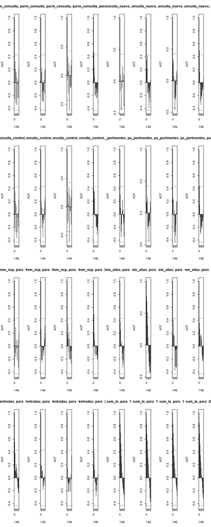

```
Autocorrelations of series 'ts(subset(cons_brechas_gine_a_imp, subset = id == unique(cons_brechas_gine_a_imp$id)[i] & lev_ano_mes %in% 6:26, select = vec_columnas[x]))', by lag

     0      1      2      3      4      5      6      7      8      9
 1.000  0.846  0.685  0.515  0.352  0.249  0.155  0.044 -0.048 -0.156
    10     11     12
-0.234 -0.301 -0.341
```

```r
#If p-value < 0.05 then no unit roots present
#tseries::adf.test(pdata.frame(cons_brechas_gine_a_imp, index = c("cod_deis","lev_ano_mes"))$rem_consulta , k=1)
#vec_columnas

invisible("Forma de ver autocorrelación")
par(mfrow=c(4,8))
for (x in 1:length(vec_columnas)){
  for (i in 1:length(unique(cons_brechas_gine_a_imp$id))){
    cat("\n\n")
    cat("#_#_#_#_#_#_#_#_#_#_#_#_#_#_#_#_#_#_#_#_#_#_#_#_#_#_#_#_#_#_#_#_#_")
    cat(paste0("### TBATS para ", vec_columnas[x], ", para  ", unique(cons_brechas_gine_a_imp$id)[i]))
    cat("\n\n")
      print(acf(
      ts(subset(cons_brechas_gine_a_imp,subset= id== unique(cons_brechas_gine_a_imp$id)[i] & lev_ano_mes %in% 6:26, select= vec_columnas[x])),lag.max = 12, main=paste0("ACF para ", vec_columnas[x], ", para  ", unique(cons_brechas_gine_a_imp$id)[i]))
      )
    }
}
```

```r
#dev.off()
```

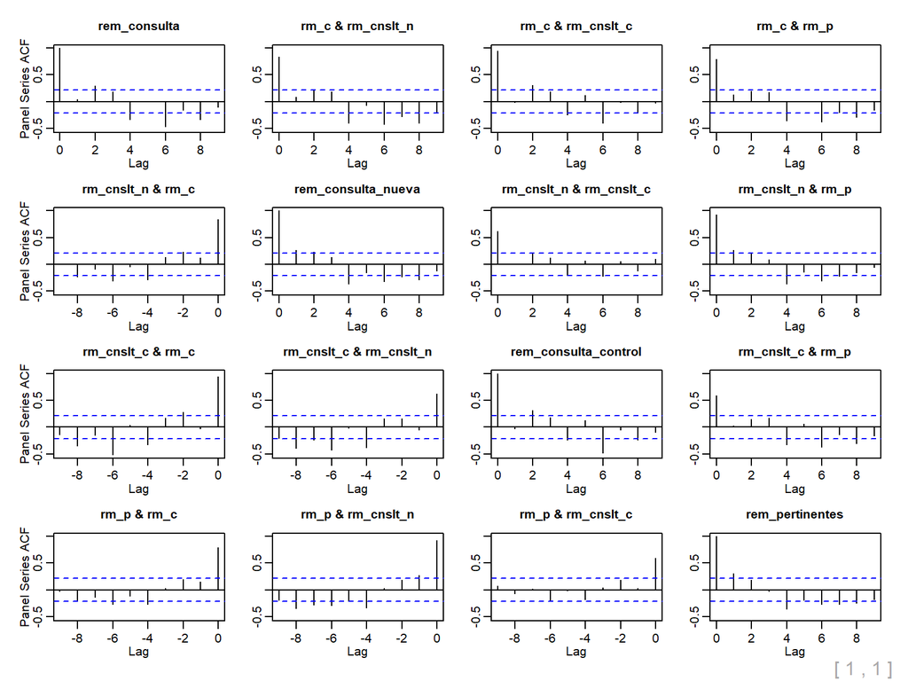

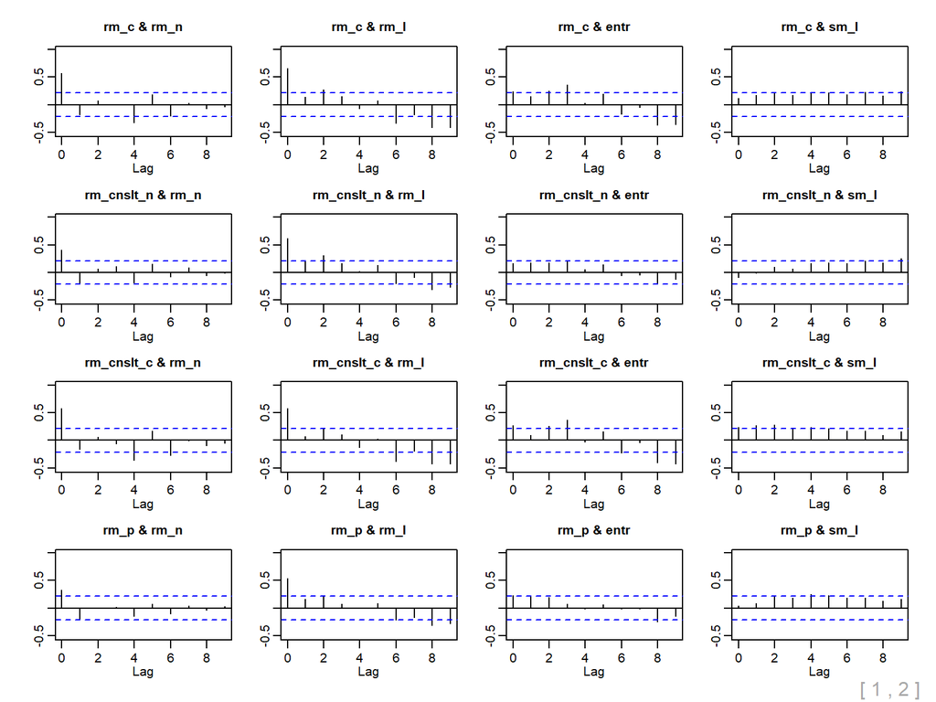

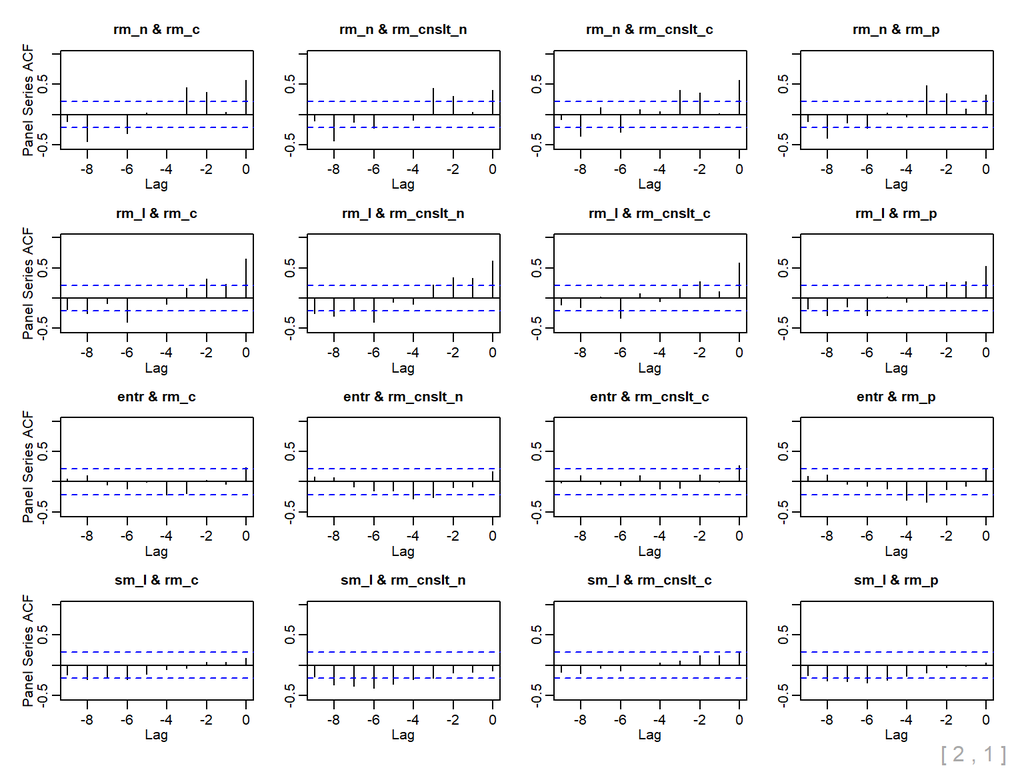

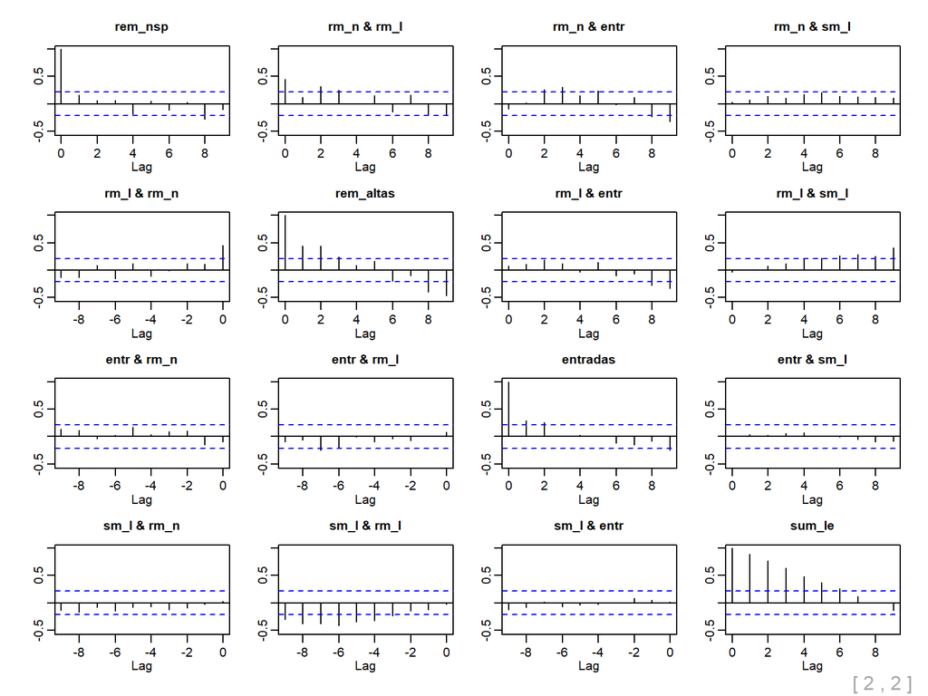

```r
#https://search.r-project.org/CRAN/refmans/collapse/html/psacf.html
#vec_columnas

collapse::psacf(data.frame(subset(cons_brechas_gine_a_imp, lev_ano_mes %in% 6:26), index = c("cod_deis","lev_ano_mes")), rem_consulta + rem_consulta_nueva+ rem_consulta_control+ rem_pertinentes+ rem_nsp+ rem_altas + entradas+ sum_le  ~ cod_deis, ~lev_ano_mes)
```

```r
#https://rdrr.io/cran/panelAR/man/panelAR.html
```

A continuación se muestra un análisis TBATS. Sus iniciales dan cuenta de T (regresores trigonométricos para múltiples temporalidades/estacionalidades), B (transformaciones box-cox que corrigen por el efecto de normalidad en los datos), A (la inclusión de errores autorregresivos y medias móviles), T(tendencia) y S (estacionalidad). Este modelo identifica automáticamente los parámetros que reducen la complejidad de los datos.

```r
#vec_columnas
#https://fondecytacc.github.io/paperestallido/BD_Compilation.html#12_TBATS

for (x in 1:length(vec_columnas)){
  for (i in 1:length(unique(cons_brechas_gine_a_imp$id))){
    cat("\n\n")
    cat("#_#_#_#_#_#_#_#_#_#_#_#_#_#_#_#_#_#_#_#_#_#_#_#_#_#_#_#_#_#_#_#_#_")
    cat(paste0("### TBATS para ", vec_columnas[x], ", para  ", unique(cons_brechas_gine_a_imp$id)[i]))
    cat("\n\n")
      print(tbats(
      ts(subset(cons_brechas_gine_a_imp,subset= id== unique(cons_brechas_gine_a_imp$id)[i] & lev_ano_mes %in% 6:26, select= vec_columnas[x]))
      ))
    }
}
```

```
#_#_#_#_#_#_#_#_#_#_#_#_#_#_#_#_#_#_#_#_#_#_#_#_#_#_#_#_#_#_#_#_#_### TBATS para rem_consulta, para  114101_07-058

BATS(1, {0,0}, -, -)

Call: tbats(y = ts(subset(cons_brechas_gine_a_imp, subset = id == unique(cons_brechas_gine_a_imp$id)[i] &
    lev_ano_mes %in% 6:26, select = vec_columnas[x])))

Parameters
  Alpha: -0.009997939

Seed States:
         [,1]
[1,] 1184.896

Sigma: 184.7972
AIC: 287.1439


#_#_#_#_#_#_#_#_#_#_#_#_#_#_#_#_#_#_#_#_#_#_#_#_#_#_#_#_#_#_#_#_#_### TBATS para rem_consulta, para  114103_07-058

BATS(1, {0,0}, -, -)

Call: tbats(y = ts(subset(cons_brechas_gine_a_imp, subset = id == unique(cons_brechas_gine_a_imp$id)[i] &
    lev_ano_mes %in% 6:26, select = vec_columnas[x])))

Parameters
  Alpha: -0.009900917

Seed States:
         [,1]
[1,] 1225.047

Sigma: 175.2487
AIC: 284.9156


#_#_#_#_#_#_#_#_#_#_#_#_#_#_#_#_#_#_#_#_#_#_#_#_#_#_#_#_#_#_#_#_#_### TBATS para rem_consulta, para  114105_07-058

BATS(1, {0,0}, -, -)

```

[output cut: 560 more lines]

```
Call: tbats(y = ts(subset(cons_brechas_gine_a_imp, subset = id == unique(cons_brechas_gine_a_imp$id)[i] &
    lev_ano_mes %in% 6:26, select = vec_columnas[x])))

Parameters
  Alpha: 0.8812918
  Beta: -0.07922375
  Damping Parameter: 0.926797

Seed States:
         [,1]
[1,] 70.95011
[2,] 80.26276

Sigma: 64.59901
AIC: 248.9993
```

```r
g <- plm(rem_consulta ~ rem_altas, data = cons_brechas_gine_a_imp, index = c("cod_deis","lev_ano_mes"), model="random")

pdwtest(g, alternative="two.sided")
#https://rdrr.io/rforge/plm/man/pbgtest.html
pbgtest(g, order = 14) #es necesario analizar dónde se ubica el rezago
#https://rdrr.io/rforge/plm/man/pbltest.html
pbltest(g)

pbsytest(log(rem_consulta) ~ rem_altas, data = cons_brechas_gine_a_imp, index = c("cod_deis","lev_ano_mes"), test = "re", re.normal = F)
pbsytest(log(rem_consulta) ~ rem_altas, data = cons_brechas_gine_a_imp, index = c("cod_deis","lev_ano_mes"), test = "re", re.normal = T)
pbsytest(log(rem_consulta) ~ rem_altas, data = cons_brechas_gine_a_imp, index = c("cod_deis","lev_ano_mes"), test = "j")
pbsytest(log(rem_consulta) ~ rem_altas, data = cons_brechas_gine_a_imp, index = c("cod_deis","lev_ano_mes"), test = "ar")

#https://rdrr.io/rforge/plm/man/pwartest.html
pwartest(log(rem_consulta) ~ rem_altas, data = cons_brechas_gine_a_imp, index = c("cod_deis","lev_ano_mes"))
#First–differencing–based test of serial correlation for (the idiosyncratic component of) the errors in either levels or first–differenced panel models.
#NO SÉ SI SIRVE
pwfdtest(log(rem_consulta) ~ rem_altas, data = cons_brechas_gine_a_imp, index = c("cod_deis","lev_ano_mes"))
#https://rdrr.io/rforge/plm/man/pbnftest.html
pbnftest(g)
pbnftest(g, test = "lbi")

#https://cran.r-project.org/web/packages/plm/vignettes/A_plmPackage.html

#https://www.princeton.edu/~otorres/Panel101R.pdf
#HETEROSCKEDACITY
# The --vcovHC– function estimates three heteroskedasticity-consistent covariance
# estimators:
# • "white1" - for general heteroskedasticity but no serial correlation. Recommended for
# random effects.
# • "white2" - is "white1" restricted to a common variance within groups. Recommended
# for random effects.
# • "arellano" - both heteroskedasticity and serial correlation. Recommended for fixed
# effects.
# The following options apply*:
# • HC0 - heteroskedasticity consistent. The default.
# • HC1,HC2, HC3 – Recommended for small samples. HC3 gives less weight to influential
# observations.
# • HC4 - small samples with influential observations
# • HAC - heteroskedasticity and autocorrelation consistent (type ?vcovHAC for more
# details)
t(sapply(c("HC0", "HC1", "HC2", "HC3", "HC4"), function(x) sqrt(diag(vcovHC(g, type = x)))))

#COLINEALIDAD
car::vif(plm(rem_consulta ~ rem_altas+ razon_do, data = cons_brechas_gine_a_imp, index = c("cod_deis","lev_ano_mes"), model="random"))

anb <- pglm(union ~ wage + exper + rural, UnionWage, family ='negbin',
model = "pooling", method = "bfgs", print.level = 3, R = 5)
```

```r
#https://blog.devgenius.io/causal-inference-on-time-series-covid-19-data-3cbba9ec35f3
#https://github.com/klarsen1/MarketMatching
#https://web.pdx.edu/~crkl/WISE2017/TSAR-1.pdf
#https://fondecytacc.github.io/paperestallido/Causal_Impact2_cons_trauma.html
#https://fondecytacc.github.io/paperestallido/BD_Compilation.html
#https://mran.microsoft.com/snapshot/2018-07-03/web/packages/plm/vignettes/plm.pdf
causal.2 <- CausalMBSTS(y, components = c("trend", "cycle"), cycle.period = 75,
                        dates = dates, int.date = int.date, s0.r = 0.01*diag(2),
                        s0.eps = 0.1*diag(2), niter = 100, burn = 10)
```

```r
feriados<- readr::read_csv("https://docs.google.com/spreadsheets/d/1Kd8SLHFLohGKCuJHa3cxbhkTH9691BCd_1ryCKUM_UA/export?format=csv&id=1Kd8SLHFLohGKCuJHa3cxbhkTH9691BCd_1ryCKUM_UA&gid=208597553",skip=2)%>%
    dplyr::mutate(`Día`=gsub(" de ", " ", `Día`))
#agrego el día viernes
feriados<-feriados%>% rbind(feriados[6,])%>%
    dplyr::mutate(`Día`=case_when(row_number()==19~"Viernes, 22 Mayo",TRUE~as.character(`Día`)))%>%
    dplyr::mutate(date_format=lubridate::parse_date_time(`Día`, '%A, %d %B'))
```

# Session Info

```r
Sys.getenv("R_LIBS_USER")
```

```
[1] "H:/.shortcut-targets-by-id/13vaH-zeqiYYS4Ss24jfuPKnDTAnAJSvM/Paper Brechas Gine/renv/library/R-4.1/x86_64-w64-mingw32;C:/Users/andre/AppData/Local/Temp/RtmpkhWK2l/renv-system-library"
```

```r
warning(getwd())
save.image("__paso1.RData")
unlink("*_cache", recursive = T, force = T, expand = TRUE)
sesion_info <- devtools::session_info()
dplyr::select(
  tibble::as_tibble(sesion_info$packages),
  c(package, loadedversion, source)
) %>%
  DT::datatable(filter = 'top', colnames = c('Row number' =1,'Variable' = 2, 'Percentage'= 3),
              caption = htmltools::tags$caption(
        style = 'caption-side: top; text-align: left;',
        '', htmltools::em('Packages')),
      options=list(
initComplete = htmlwidgets::JS(
        "function(settings, json) {",
        "$(this.api().tables().body()).css({
            'font-family': 'Helvetica Neue',
            'font-size': '50%',
            'code-inline-font-size': '15%',
            'white-space': 'nowrap',
            'line-height': '0.75em',
            'min-height': '0.5em'
            });",#;
        "}")))
```

| Row number | Variable | Percentage | source |
| --- | --- | --- | --- |
| 1 | abind | 1.4-5 | CRAN (R 4.1.1) |
| 2 | Amelia | 1.8.0 | CRAN (R 4.1.3) |
| 3 | assertthat | 0.2.1 | CRAN (R 4.1.3) |
| 4 | astsa | 1.16 | CRAN (R 4.1.3) |
| 5 | backports | 1.4.1 | CRAN (R 4.1.2) |
| 6 | base64enc | 0.1-3 | CRAN (R 4.1.0) |
| 7 | bayestestR | 0.13.0 | CRAN (R 4.1.3) |
| 8 | bdsmatrix | 1.3-6 | CRAN (R 4.1.3) |
| 9 | bit | 4.0.4 | CRAN (R 4.1.3) |
| 10 | bit64 | 4.0.5 | CRAN (R 4.1.3) |

[output cut: 207 more lines]

Adams, Annette L. 2008. “Encyclopedia of Epidemiology.” Thousand Oaks: SAGE Publications, Inc. https://doi.org/10.4135/9781412953948 NV - 2.

Aschwanden, Christie. 2015. “Science Isnt Broken Its just a hell of a lot harder than we give it credit for.” FiveThirtyEight. https://fivethirtyeight.com/features/science-isnt-broken/#part1.

Bounthavong, Mark. 2018. “Using inverse probability of treatment weights & Marginal structural models to handle time-varying covariates.” https://rpubs.com/mbounthavong/IPTW_MSM_Tutorial.

Cummiskey, Kevin, Bryan Adams, James Pleuss, Dusty Turner, Nicholas Clark, and Krista Watts. 2020. “Causal Inference in Introductory Statistics Courses.” *Journal of Statistics Education* 28 (1): 2–8. https://doi.org/10.1080/10691898.2020.1713936.

Gelman, Andrew, and Guido Imbens. 2013. “Why Ask Why? Forward Causal Inference and Reverse Causal Questions.” Working Paper 19614. Working Paper Series. National Bureau of Economic Research. https://doi.org/10.3386/w19614.

Hernán, Miguel A. 2001. “Conocimiento Experto, Confusión y Métodos Causales.” *Gaceta Sanitaria* 15: 44–48. https://doi.org/10.1007/BF02595718.

Hernán, Miguel A, Sonia Hernández-Díaz, and James M Robins. 2004. “A structural approach to selection bias.” *Epidemiology (Cambridge, Mass.)* 15 (5): 615–25. https://doi.org/10.1097/01.ede.0000135174.63482.43.

Hernán, Miguel Ángel, and James M Robins. 2020. *Causal Inference: What If*. Boca Raton: Chapman & Hall/CRC. https://cdn1.sph.harvard.edu/wp-content/uploads/sites/1268/2019/10/ci_hernanrobins_1oct19.pdf.

Hernán, Miguel A, and James M Robins. 2010. “Causal inference.” CRC Boca Raton, FL.

Imbens, Guido W., and Donald B. Rubin. 2015. “Causality: The Basic Framework.” In *Causal Inference for Statistics, Social, and Biomedical Sciences: An Introduction*, 3–22. Cambridge University Press. https://doi.org/10.1017/CBO9781139025751.002.

Kaufman, Jay. 2020. “Conceptos de Causalidad y Sesgos en Estudios Observacionales.” Evaluación de intervenciones: estudios cuasi-experimentales. Escuela de Salud Pública. Universidad de Chile. https://fivethirtyeight.com/features/science-isnt-broken/#part1.

Mansournia, Mohammad Ali, Mahyar Etminan, Goodarz Danaei, Jay S Kaufman, and Gary Collins. 2017. “Handling Time Varying Confounding in Observational Research.” *BMJ* 359. https://doi.org/10.1136/bmj.j4587.

Matthay, Ellicott C., Erin Hagan, Laura M. Gottlieb, May Lynn Tan, David Vlahov, Nancy E. Adler, and M. Maria Glymour. 2020. “Alternative Causal Inference Methods in Population Health Research: Evaluating Tradeoffs and Triangulating Evidence.” *SSM - Population Health* 10: 100526. https://doi.org/https://doi.org/10.1016/j.ssmph.2019.100526.

McGrath, Sean, Victoria Lin, Zilu Zhang, Lucia C Petito, Roger W Logan, Miguel A Hernán, and Jessica G Young. 2020. “gfoRmula: An R Package for Estimating the Effects of Sustained Treatment Strategies via the Parametric g-formula.” *Patterns (New York, N.Y.)* 1 (3). https://doi.org/10.1016/j.patter.2020.100008.

Muriel, Alfonso, Domingo Hernández, and Víctor Abraira. 2011. “Modelos Estructurales Marginales: Una Herramienta útil Que Proporciona Evidencia a Los Estudios Observacionales.” *Nefrologia* 2 (7): 7–13. https://doi.org/10.3265/NefrologiaSuplementoExtraordinario.pre2011.Dec.11267.

Naimi, Ashley I, Stephen R Cole, and Edward H Kennedy. 2016. “An introduction to g methods.” *International Journal of Epidemiology* 46 (2): 756–62. https://doi.org/10.1093/ije/dyw323.

Pearl, Judea. 2003. “Statistics and Causal Inference: A Review.” *TEST: An Official Journal of the Spanish Society of Statistics and Operations Research* 12 (February): 281–345. https://doi.org/10.1007/BF02595718.

Platt, Robert W., Enrique F. Schisterman, and Stephen R. Cole. 2009. “Time-modified Confounding.” *American Journal of Epidemiology* 170 (6): 687–94. https://doi.org/10.1093/aje/kwp175.

Robins, James. 1986. “A new approach to causal inference in mortality studies with a sustained exposure period—application to control of the healthy worker survivor effect.” *"Math. Modelling"* 7: 1393–1512.

Robins, James M, Miguel Ángel Hernán, and Babette Brumback. 2000. “Marginal Structural Models and Causal Inference in Epidemiology.” *Epidemiology* 11 (5). https://doi.org/10.1097/00001648-200009000-00011.

Rothman, A. n.d. “Causal Inference in Data Science: Doubly Robust Estimation of G-Methods.” https://towardsdatascience.com/doubly-robust-estimators-for-causal-inference-in-statistical-estimation-3c00847e9db.

Rubin, Donald B. 1980. “Randomization Analysis of Experimental Data: The Fisher Randomization Test Comment.” *Journal of the American Statistical Association* 75 (371): 591–93.

Schisterman, Enrique F, Stephen R Cole, and Robert W Platt. 2009. “Overadjustment bias and unnecessary adjustment in epidemiologic studies.” *Epidemiology (Cambridge, Mass.)* 20 (4): 488–95. https://doi.org/10.1097/EDE.0b013e3181a819a1.

Tompsett, Daniel, Stijn Vansteelandt, Oliver Dukes, and Bianca De Stavola. 2022. “Gesttools: General Purpose G-Estimation in R.” *Observational Studies* 8 (1): 1–28. https://doi.org/10.1353/obs.2022.0003.

van der Wal, Willem M., and Ronald B. Geskus. 2011. “ipw: An R Package for Inverse Probability Weighting.” *Journal of Statistical Software* 43 (13): 1–23. http://www.jstatsoft.org/v43/i13/.

Vansteelandt, Stijn, and Niels Keiding. 2011. “Invited Commentary: G-Computation–Lost in Translation?” *Am J Epidemiol* 173 (7): 739–42.